# Statistik 1 - Blatt 2

## Aufgabe 5

**A:** *In Stichproben von n = 10, 20, 100 Studierenden befinden sich jeweils 60% Studentinnen. Berechnen Sie für alle drei Stichproben die p-Werte des zweiseitigen Binomialtests mit Trefferwahrscheinlichkeit p = 1/2 (d.h. die Nullhypothese $H_0 : p = 1/2$ besagt, dass es genau 50% Stu- dentinnen in der Grundpopulation gibt).*

```r
stud_10 <- (binom.test(6,10, p=0.5))
stud_10_p <- stud_10$p.value
stud_20 <- (binom.test(12,20, p=0.5))
stud_20_p <- stud_20$p.value
stud_100 <- (binom.test(60,100, p=0.5))
stud_100_p <- stud_100$p.value
```

**B:** *In einer Stichprobe von n = 100 Studierenden befinden sich k = 0, . . . , 100 Studentinnen. Berechnen Sie für alle k den p-Wert des zweiseitigen Bi- nomialtests $H_0 : p = 1/2$ und stellen Sie*

- a: die p-Werte
- b: den Zehnerlogarithmus (log10) der p-Werte in jeweils einem Streudiagramm (plot) dar

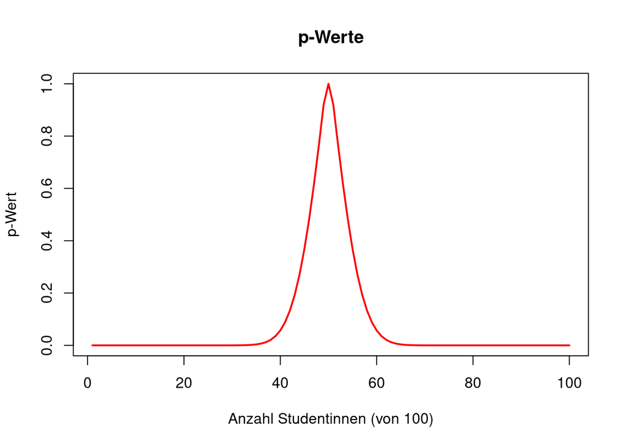

```r
sum_stud <- c()
for (x in 1:100) {
  sum_stud[x] <- binom.test(x,100, p=0.5)$p.value
}

plot(1:length((sum_stud)), sum_stud, xlab="Anzahl Studentinnen (von 100)", ylab="p-Wert", type="l", col="red", lwd=2, main="p-Werte")
```

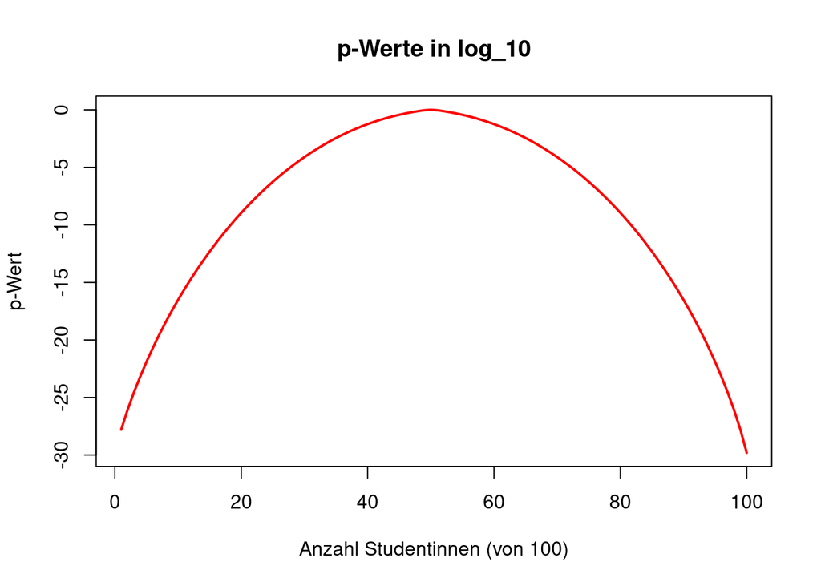

```r
plot(1:length((sum_stud)), log(sum_stud, 10), xlab="Anzahl Studentinnen (von 100)", ylab="p-Wert", type="l", col="red", lwd=2, main="p-Werte in log_10")
```

## Aufgabe 6

*Stellen Sie die Binomialverteilungen für n = 10, 20, 100 und Tref- ferwahrscheinlichkeit p = 1/2 in geeigneten Diagrammen mit R dar. Wählen Sie für alle Diagramme die gleiche Skalierung der Y-Achse (ylim=). Was fällt Ihnen an den Verteilungen auf? Für welche k werden die maximalen Wahr- scheinlichkeiten angenommen? Geben Sie diese Wahrscheinlichkeiten an.*

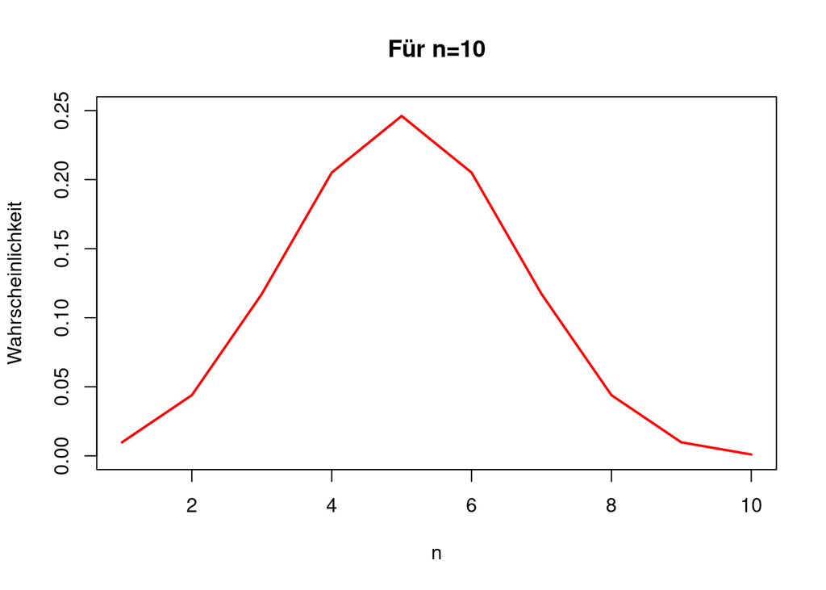

```r
plot(dbinom(1:10, 10, prob=0.5), type="l", col="red", lwd=2, xlab="n", ylab="Wahrscheinlichkeit", main="Für n=10", ylim=c(0,.25))
```

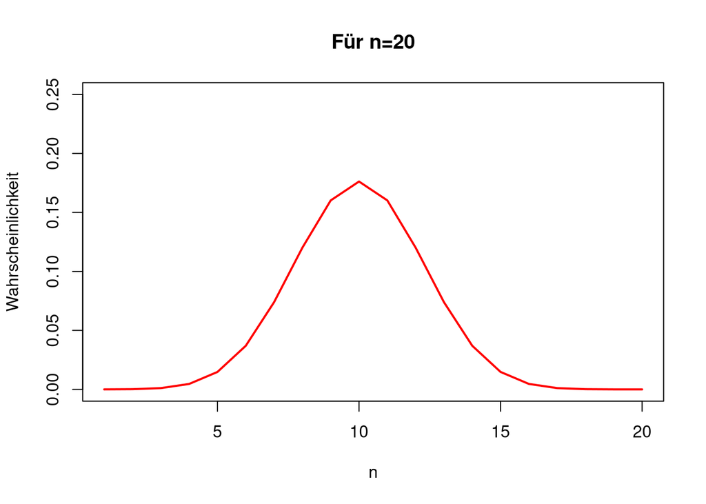

```r
plot(dbinom(1:20, 20, prob=0.5), type="l", col="red", lwd=2, xlab="n", ylab="Wahrscheinlichkeit", main="Für n=20", ylim=c(0,.25))
```

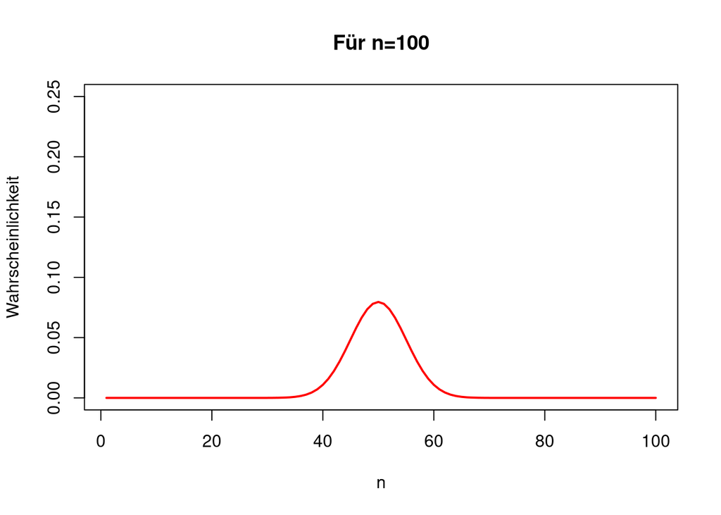

```r
plot(dbinom(1:100, 100, prob=0.5), type="l", col="red", lwd=2, xlab="n", ylab="Wahrscheinlichkeit", main="Für n=100", ylim=c(0,.25))
```

### Beobachtung:

Die maximale Wahrscheinlichkeit befindet sich immer in der Mitte - da, wo die “Trefferrate” genau 50% beträgt. Mit größerem n wird die maximale Wahrscheinlichkeit kleiner, da sie sich auf mehr Elemente in der Mitte aufteilen muss.

## Aufgabe 7

**A)** *Sei n der Umfang einer Stichprobe von Studierenden und k die Anzahl der Studentinnen in dieser Stichprobe. Geben Sie für beliebiges n ≥ 4 eine Formel für den p-Wert des zweiseitigen Binomialtests (H0 : p = 1/2) an, wenn sich in der Stichprobe (a) k = 0 (b) k = 1 (c) k = 2 Studentinnen befinden.*

Allgemeine Formel zur Bestimmung von Wahrscheinlichkeit: $P_r(X=k) = \binom{n}{k}\cdot p^k\cdot(1-p)^{n-k}\\$

Beispiel für k = 0: $P_r(X=0) = \binom{n}{0}\cdot(\frac{1}{2})^0\cdot(1-\frac{1}{2})^{n-0}$

Also kann die Formel allgemein wie folgt ausgedrückt werden:

$$\sum_{i=0}^{k}{\binom{n}{k}\cdot p^k\cdot(1-p)^{n-k}} +
\sum_{i=k}^{n}{\binom{n}{k}\cdot p^k\cdot(1-p)^{n-k}}$$

Diese Formel wurde an das folgende R Beispiel aus der Vorlesung angelehnt:

```r
p.Wert <- sum(dbinom(0:465, size=1003, prob=0.5))+
+ sum(dbinom(538:1003, size=1003, prob=0.5))
```

**B:** *Bestimmen Sie (durch systematisches Probieren mit R) das kleinste n, für das der Binomialtest die Nullhypothese H0 : p = 1/2 auf dem Signi- fikanzniveau α = 0,001 ablehnt, wenn (a) k = 0 (b) k = 1 (c) k = 2 ist. Benutzen Sie die Formeln aus der vorigen Teilaufgabe.*

Wir können mit Hilfe einer Schleife systematisch das kleinste n herausfinden. Probehalber wurde das n hier bis 10.000 getestet, was sich für k={0,1,2} als ausreichend herausgestellt hat.

```r
nTest <- function(k, sigNiveau) {
  print(paste0("Test für k = ", k))
  for (x in k:10000) {
    p.Wert <- sum(dbinom(k, size=x, prob=0.5))+
    + sum(dbinom(k, size=x, prob=0.5))
    if (p.Wert < sigNiveau) {
      print(paste0("p-Wert: ", p.Wert))
      print(paste0("Kleinstes n gefunden. n = ", x))
      break
    }
    else {
      print(paste0("p-Wert: ", p.Wert))
      print(paste0(x))
    }
  }
}

#Test für k={0,1,2}
nTest(0, 0.001)
```

```
## [1] "Test für k = 0"
## [1] "p-Wert: 2"
## [1] "0"
## [1] "p-Wert: 1"
## [1] "1"
## [1] "p-Wert: 0.5"
## [1] "2"
## [1] "p-Wert: 0.25"
## [1] "3"
## [1] "p-Wert: 0.125"
## [1] "4"
## [1] "p-Wert: 0.0625"
## [1] "5"
## [1] "p-Wert: 0.03125"
## [1] "6"
## [1] "p-Wert: 0.015625"
## [1] "7"
## [1] "p-Wert: 0.0078125"
## [1] "8"
## [1] "p-Wert: 0.00390625"
## [1] "9"
## [1] "p-Wert: 0.001953125"
## [1] "10"
## [1] "p-Wert: 0.0009765625"
## [1] "Kleinstes n gefunden. n = 11"
```

```r
nTest(1, 0.001)
```

```
## [1] "Test für k = 1"
## [1] "p-Wert: 1"
## [1] "1"
## [1] "p-Wert: 1"
## [1] "2"
## [1] "p-Wert: 0.75"
## [1] "3"
## [1] "p-Wert: 0.5"
## [1] "4"
## [1] "p-Wert: 0.3125"
## [1] "5"
## [1] "p-Wert: 0.1875"
## [1] "6"
## [1] "p-Wert: 0.109375"
## [1] "7"
```

[output cut: 16 more lines]

```r
nTest(2, 0.001)
```

```
## [1] "Test für k = 2"
## [1] "p-Wert: 0.5"
## [1] "2"
## [1] "p-Wert: 0.75"
## [1] "3"
## [1] "p-Wert: 0.75"
## [1] "4"
## [1] "p-Wert: 0.625"
## [1] "5"
## [1] "p-Wert: 0.46875"
## [1] "6"
## [1] "p-Wert: 0.328125"
## [1] "7"
## [1] "p-Wert: 0.21875"
## [1] "8"
```

[output cut: 22 more lines]

## Aufgabe 8

*Bestimmen Sie für eine Stichprobe vom Umfang $n = 100$ das kleinste $k > 50$ von Treffern, so dass der zweiseitige Binomialtest mit Trefferwahrscheinlichkeit $p = 1/2$ auf dem Signifikanzniveau $α = 0,05$ signifikant wird. Der Bereich ${0, 1, ... , n − k, k, k + 1, ..., n}$ heißt der Ablehnungsbereich zum Signifikanzniveau $α = 0,05$. Durch welche Eigenschaft ist dieser Bereich charakterisiert*

```r
print(paste0("Test für n = 100"))
```

```
## [1] "Test für n = 100"
```

```r
for (x in 51:100) {
  p.Wert <- sum(dbinom(x, size=100, prob=0.5))+
  + sum(dbinom(x, size=100, prob=0.5))
  if (p.Wert > .05) {
    print(paste0("p-Wert: ", p.Wert))
    print(paste0("Kleinstes k gefunden. k = ", x))
    break
  }
  else {
    print(paste0("p-Wert: ", p.Wert))
    print(paste0(x))
  }
}
```

```
## [1] "p-Wert: 0.156057328210154"
## [1] "Kleinstes k gefunden. k = 51"
```